# Attempt at Bayesian Optimization for Nanotpography exploration

This notebook shows results for optimizing the morphome with respect to osteogenesis, but performed per geometry!

Call functions needed from R.

```r
#set up all the libraries that you'll be needing here
library(reticulate)
library(ggplot2)
library(tidyverse)
library(caret)
library(tidyverse)
library(reshape2)
library(glue)
library(brms)
use_condaenv(condaenv = 'python36', required = TRUE)
```

Import the dataset we need

```r
#data import
#choose which data to perform Bayesian optimization on
allData <- read_csv("meanBayesOptData_noFlat.csv")
```

Get predictive models created using Bayesian linear regression (brms):

```r
load("~/RProjects/BayesianOptimization_imageToPcr/scaledData_griditerate/imageBasedModels2.RData")


#studentTModel_base_topoPrediction_geom1 predicts HEX topography from image features


#note that imageBasedModels2 contain the following models:
#studentModels that have multiple response predictions for (log) genes, for HEX (geom1) and SQ (geom2) separately from X + X^2
#studentTModels that have multiple prediction of (byMax) disorder and diameter from image features X, for HEX (geom1) and SQ (geom2) separately
```

We need to show that we can model morphome to PCR using a GP regression. This goes wihtout saying anyway, as GP is probably better than just a simple Bayes opt.

```r
#perform a gp regression to show that we can do it with the current dataset
rm('gp_modeling_split.py')
source_python('gp_modeling_split.py')

for (g in 1:2){
   geomData <- subset(allData, allData$Geometry_Number == g)
   xraw = as.data.frame(geomData[,18:260])
   names(xraw)[1] <- "X1"
   xmean = lapply(xraw,mean)
   xsd = lapply(xraw, sd)
   x = as.data.frame((xraw-xmean)/xsd)
   yraw = as.data.frame(geomData[,14:17])
   ylog = log(yraw, 10)
   ymax = unlist(lapply(ylog, max))
   y = ylog/ymax
   imagetopcr_model <- gp_modeling_split(x=x, y=y)
   assign(glue("imagetopcr_model_geom{g}"), imagetopcr_model)
   assign(glue("x_geom_{g}"), x)
   assign(glue("y_geom_{g}"), y)

   #to get values of the kernel that has seen the data
   #kern_bayesopt <- topotopcr_model_base[[2]]
   #kern_rnd <- topotopcr_model_base[[2]]

   #to get initial values for the kernel
   kern_bayesopt <- imagetopcr_model[[9]]
   kern_rnd <- imagetopcr_model[[9]]

   assign(glue("kern_bayesopt_{g}"), kern_bayesopt)
   assign(glue("kern_rnd_{g}"), kern_rnd)
 }
```

Plot of the GP regression

```r
ypred <- NULL
yactual <- NULL
geometryHolder <- NULL
ydata <- NULL

for(g in 1:2){
   gpModelToUse<-get(glue("imagetopcr_model_geom{g}"))
   ypred<-  unlist(gpModelToUse[[6]])
   names(ypred)[1] <- "train"
   yactual <- unlist(gpModelToUse[[8]])
   names(yactual)[1] <- "test"
   ydataHolder <- as.data.frame(cbind(ypred, yactual))
   ydataHolder$geometry <- g
   ydata <- rbind(ydata, ydataHolder)
}
   ggplot(ydata, aes(x=ypred, y=yactual)) + geom_point() + geom_abline(color="red") + facet_wrap(~geometry)
```

[output not shown]

```r
print(paste0("MAE using GP regression is (original data):", MAE(ydata[,1], ydata[,2])))
```

[output not shown]

```r
print(paste0("MAE using GP regression is (scaled Y data):", imagetopcr_model[[3]]))
```

[output not shown]

Bayesian Optimization Scenario 1. Let’s try to see if the Bayesian Optimization protocol can be used to more efficiently sample the known morphome space to maximize PCR. Recall that for Bayesian optimization, we only use the weighted sum of Genes4-Genes7 (single objective optimization).

```r
rm('bayesian_optimization_nogrid')
source_python('bayesian_optimization_real_noGrid2.py')

#set some parameters here
exp = 50
offset = 5
all_ymax_bayesopt <- NULL
all_ymax_rnd <- NULL
all_ind_bayesopt <- NULL
all_ind_rnd <- NULL
all_experiment <- NULL
all_iterations <- NULL


for(g in 1:2){
   geomData <- subset(allData, allData$Geometry_Number == g)
   xraw = as.data.frame(geomData[,18:260])
   names(xraw)[1] <- "X1"
   xmean = lapply(xraw,mean)
   xsd = lapply(xraw, sd)
   x = as.data.frame((xraw-xmean)/xsd)
   yraw = as.data.frame(geomData[,265])
   ylog = log10(yraw)
   ymax = unlist(lapply(ylog, max))
   y = ylog/ymax
   maxiter = nrow(x)-1
   allImageToPcr <- NULL
   indexBayesOptMax <- NULL
   indexRndMax <- NULL
   holderIndexBayesOptMax <- NULL
   holderIndexRndMax <- NULL

   for (num in 1:exp){

    i=1
    set.seed(num*162+972)
    ind_bayesopt = list(sample(1:nrow(x)-1, 1, replace=F))
    ind_rnd = list(sample(1:nrow(x)-1, 1, replace=F))
    all_ymax_bayesopt <- y[unlist(ind_bayesopt)+1,]
    all_ymax_rnd <- y[unlist(ind_rnd)+1,]
    active_ind_bayesopt <- ind_bayesopt
    active_ind_rnd <- ind_rnd
    all_iterations <- i
    all_experiment <- num

    kern_bayesopt <- get(glue("kern_bayesopt_{g}"))
    kern_rnd <- get(glue("kern_rnd_{g}"))

      for (i in 1:maxiter){

         res <- bayesian_optimization_nogrid(x=x, y=y, ind_active_bayesopt=active_ind_bayesopt, ind_active_rnd=active_ind_rnd, kernel_bayesopt=kern_bayesopt, n_offset_bayesopt=offset, iter=i)

         active_ind_bayesopt <- rbind(active_ind_bayesopt, unlist(res[[3]]))
         active_ind_rnd <- rbind(active_ind_rnd, unlist(res[[4]]))
         ind_bayesopt <- rbind(ind_bayesopt, unlist(res[[3]]))
         ind_rnd <- rbind(ind_rnd, unlist(res[[4]]))
         y_best_bayesopt_iter <- res[[5]]
         y_best_rnd_iter <- res[[6]]
         kern_bayesopt <- res[[7]]
         all_ymax_bayesopt <- rbind(all_ymax_bayesopt, unlist(y_best_bayesopt_iter))
         all_ymax_rnd <- rbind(all_ymax_rnd, unlist(y_best_rnd_iter))
         all_experiment <- rbind(all_experiment, num)
         all_iterations <- rbind(all_iterations, i)
         #print(ind_bayesopt)
         #print(y_best_bayesopt_iter)

      }

   holder <- bind_cols(ymax_bayesopt = all_ymax_bayesopt, ymax_rnd = all_ymax_rnd, chosen_bayesopt_index = unlist(ind_bayesopt), chosen_rnd_index = unlist(ind_rnd), experiment = all_experiment, iterations = all_iterations)
   holder$geometry <- g
   allImageToPcr <- rbind(allImageToPcr, holder)

   holderIndexBayesOptMax <- rbind(holderIndexBayesOptMax,  min(which(holder$ymax_bayesopt == max(holder$ymax_bayesopt))))
   holderIndexBayesOptMax <- as.data.frame(holderIndexBayesOptMax)
   holderIndexBayesOptMax$geometry <- g
   indexBayesOptMax <- rbind(indexBayesOptMax, holderIndexBayesOptMax)

   holderIndexRndMax <- rbind(holderIndexRndMax,  min(which(holder$ymax_rnd == max(holder$ymax_rnd))))
   holderIndexRndMax <- as.data.frame(holderIndexRndMax)
   holderIndexRndMax$geometry <- g
   indexRndMax <- rbind(indexRndMax, holderIndexRndMax)


   print(paste0("Experiment Number:", num))
   }

  assign(glue("allImageToPcr_geom{g}"), allImageToPcr)
  assign(glue("indexBayesOptMax_geom{g}"), holderIndexBayesOptMax)
  assign(glue("indexRndMax_geom{g}"), holderIndexRndMax)

}

allImageToPcr <- NULL
allImageToPcr <- bind_rows(allImageToPcr_geom1, allImageToPcr_geom2)
indexBayesOptMax <- rbind(indexBayesOptMax_geom1, indexBayesOptMax_geom2)
indexRndMax <- rbind(indexRndMax_geom1, indexRndMax_geom2)

write.csv(allImageToPcr, file="allImageToPcr_s1_combGeom.csv")
write.csv(indexBayesOptMax, file="indexBayesOptMax_s1_combGeom.csv")
write.csv(indexRndMax, file="indexRndMax_s1_combGeom.csv")


allImageToPcr$ExptGeomCombo <- paste0(allImageToPcr$geometry, sep="_", allImageToPcr$experiment)
allImageToPcr$ExptGeomComboArrange <- factor(allImageToPcr$ExptGeomCombo, levels=c("1_1", "1_2", "1_3", "1_4", "1_5", "2_1", "2_2", "2_3", "2_4", "2_5"))

meltDataYmax <- melt(allImageToPcr[c(1,2,6,7,9)], value.name = "ymax", variable.name = "type", id.vars=c("geometry", "iterations", "ExptGeomComboArrange"))

ggplot(meltDataYmax, aes(x = iterations, y = ymax, color = type)) +
   facet_wrap(~ExptGeomComboArrange, scales="free") +
   geom_point() +
   geom_line() +
   theme_bw()
```

[output not shown]

[figure not shown]

```r
for (g in 1:2){
   averageDataSubset <- subset(averageData, averageData$geometry == g)
   yMaxIndex<-which(averageDataSubset$mean.value==max(averageDataSubset$mean.value))
   BayesOptMaxIndex <- averageDataSubset[min(yMaxIndex), 1]
   RndMaxIndex <- averageDataSubset[min(yMaxIndex[lapply(yMaxIndex, "%%", 2)==0]), 1]
   print(glue("Max iterations needed by Bayes Opt to get to optimum of geometry {g} is {BayesOptMaxIndex}"))
   print(glue("Max iterations needed by Rnd to get to optimum of geometry {g} is {RndMaxIndex}"))
}
```

```
Max iterations needed by Bayes Opt to get to optimum of geometry 1 is 17
Max iterations needed by Rnd to get to optimum of geometry 1 is 17
Max iterations needed by Bayes Opt to get to optimum of geometry 2 is 41
Max iterations needed by Rnd to get to optimum of geometry 2 is 43
```

Using the predictive model, do we actually obtain the same topography type as the data says we should?

```r
#in predictive models, check the position of the disorder, diameter and angles.
#in the current models that we use we have:
#position 1: disorder
#position 2: diameter
# bayesOptTopoPredicted <- NULL
# rndTopoPredicted <- NULL
#
# for(g in 1:2){
#
#    indexBayesOptMaxHolder <- subset(indexBayesOptMax, indexBayesOptMax$geometry == g)
#    indexRndMaxHolder <- subset(indexRndMax, indexRndMax$geometry == g)
#    indexBayesOptMaxHolder <- indexBayesOptMaxHolder + 1
#    indexRndMaxHolder <- indexRndMaxHolder + 1
#
#    for(i in 1:exp){
#       bayesOptTopoPredictedHolder <- NULL
#       rndTopoPredictedHolder <- NULL
#       modelToUse <- get(glue("studentTModel_base_topoPrediction_geom{g}"))
#
#       topoBayesOpt <- t(predict(modelToUse, newdata = x[indexBayesOptMaxHolder[i,1],], draws=50)[c(1,5)])
#       topoRnd <- t(predict(modelToUse, newdata = x[indexRndMaxHolder[i,1],], draws=50)[c(1,5)])
#
#       #when we scale the data for the linear regression, we scale everything together, not per geometry. but the data that we use here will depend on the model that we ultimately use (Diameter and Disorder by Max??)
#       bayesOptTopoPredictedHolder <- bind_cols(Disorder = topoBayesOpt[,1]*238.8+132.1, Diameter = topoBayesOpt[,2]*589.7+401.14, Index =indexBayesOptMaxHolder[i,1], geom=g)
#       rndTopoPredictedHolder <- bind_cols(Disorder = topoRnd[,1]*238.8+132.1, Diameter = topoRnd[,2]*589.7+401.14, Index = indexRndMaxHolder[i,1], geom=g)
#
#       bayesOptTopoPredicted <- bind_rows(bayesOptTopoPredicted, bayesOptTopoPredictedHolder)
#       rndTopoPredicted <- bind_rows(rndTopoPredicted, rndTopoPredictedHolder)
#    }
#       assign(glue("bayesOptTopoPredicted_geom{g}"), bayesOptTopoPredicted)
#       assign(glue("rndTopoPredicted_geom{g}"), rndTopoPredicted)
#       write.csv(bayesOptTopoPredicted, file=glue("bayesOptTopoPredicted_geom{g}_s1.csv"))
#       write.csv(rndTopoPredicted, file=glue("rndTopoPredicted_geom{g}_s1.csv"))
# }
#
# assign(glue("bayesOptTopoPredicted_combGeom_s1"), bayesOptTopoPredicted)
# assign(glue("rndTopoPredicted_combGeom_s1"), rndTopoPredicted)
#
# print(paste0("The predicted SQ Disorder and Diameter that lead to max osteogenesis is:",  bayesOptTopoPredicted[1:5,1:2]))
# print(paste0("The predicted HEX Disorder and Diameter that lead to max osteogenesis is:",  bayesOptTopoPredicted[6:10, 1:2]))
```

```python
# import numpy as np
# import pandas as pd
#
# #should we generate this within the function instead?
# num=5
#
# np.random.seed(num*1491+10)
# numRow = 100
# numCol = 243
# ranges = np.asarray([[-3,3]])
# starts = ranges[:, 0]
# widths = ranges[:, 1]-ranges[:, 0]
# gridImages = starts + widths*np.random.random(size=(numRow, numCol))
# gridImages = pd.DataFrame(gridImages)
# gridImages.to_csv('gridImages_{i}.csv'.format(i=num))


#we need to refer to this object as py$gridImages in the R session
#we need to change this for every iteration
```

Unfortunately each time we need to predict the PCR from image features, we will need to put in column names.

```r
 target<-c("X1", "X2", "X3", "X4", "X5", "X6", "X7", "X8", "X9", "X10", "X11", "X12", "X13", "X14", "X15", "X16", "X17", "X18", "X19", "X20", "X21", "X22", "X23", "X24", "X25", "X26", "X27", "X28", "X29", "X30", "X31", "X32", "X33", "X34", "X35", "X36", "X37", "X38", "X39", "X40", "X41", "X42", "X43", "X44", "X45", "X46", "X47", "X48", "X49", "X50", "X51", "X52", "X53", "X54", "X55", "X56", "X57", "X58", "X59", "X60", "X61", "X62", "X63", "X64", "X65", "X66", "X67", "X68", "X69", "X70", "X71", "X72", "X73", "X74", "X75", "X76", "X77", "X78", "X79", "X80", "X81", "X82", "X83", "X84", "X85", "X86", "X87", "X88", "X89", "X90", "X91", "X92", "X93", "X94", "X95", "X96", "X97", "X98", "X99", "X100", "X101", "X102", "X103", "X104", "X105", "X106", "X107", "X108", "X109", "X110", "X111", "X112", "X113", "X114", "X115", "X116", "X117", "X118", "X119", "X120", "X121", "X122", "X123", "X124", "X125", "X126", "X127", "X128", "X129", "X130", "X131", "X132", "X133", "X134", "X135", "X136", "X137", "X138", "X139", "X140", "X141", "X142", "X143", "X144", "X145", "X146", "X147", "X148", "X149", "X150", "X151", "X152", "X153", "X154", "X155", "X156", "X157", "X158", "X159", "X160", "X161", "X162", "X163", "X164", "X165", "X166", "X167", "X168", "X169", "X170", "X171", "X172", "X173", "X174", "X175", "X176", "X177", "X178", "X179", "X180", "X181", "X182", "X183", "X184", "X185", "X186", "X187", "X188", "X189", "X190", "X191", "X192", "X193", "X194", "X195", "X196", "X197", "X198", "X199", "X200", "X201", "X202", "X203", "X204", "X205", "X206", "X207", "X208", "X209", "X210", "X211", "X212", "X213", "X214", "X215", "X216", "X217", "X218", "X219", "X220", "X221", "X222", "X223", "X224", "X225", "X226", "X227", "X228", "X229", "X230", "X231", "X232", "X233", "X234", "X235", "X236", "X237", "X238", "X239", "X240", "X241", "X242", "X243")
```

Bayesian Optimization Scenario 4: Have to add another scenario where you only do gridToUse search 5x on one gridToUse. But predict all the data first and just get the outcome using index.

[figure not shown]

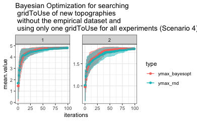

```r
averageData_s4 <- meltDataYmaxGrid_s4 %>%
    group_by(iterations, type, geometry) %>%
    summarise(mean.value=mean(ymax), stdev.value = sd(ymax))

ggplot(averageData_s4, aes(x = iterations, y = mean.value, color = type)) +
   facet_wrap(~geometry, scales="free") +
   geom_errorbar(aes(ymin = mean.value - stdev.value, ymax = mean.value + stdev.value), alpha=0.5) +
   geom_point() +
   geom_line() +
   theme_bw() +
   labs(title="Bayesian Optimization for searching \n gridToUse of new topographies \n without the empirical dataset and \n using only one gridToUse for all experiments (Scenario 4)")
```

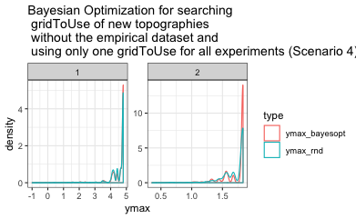

```r
ggplot(meltDataYmaxGrid_s4, aes(x = ymax, color = type)) +
   geom_density(stat="density") +
   facet_wrap(~geometry, scales="free") +
   theme_bw() +
   labs(title="Bayesian Optimization for searching \n gridToUse of new topographies \n without the empirical dataset and \n using only one gridToUse for all experiments (Scenario 4)")
```

```r
library(sm)
subsetGeom1 <- subset(meltDataYmaxGrid_s4, meltDataYmaxGrid_s4$geometry==1)
pdf(glue("topoToPCR_density_geom1_s4.pdf"))
sm.density.compare(subsetGeom1$ymax, subsetGeom1$type, xlab="Geometry HEX_s1")
dev.off()
```

```r
subsetGeom2 <- subset(meltDataYmaxGrid_s4, meltDataYmaxGrid_s4$geometry==2)
pdf(glue("topoToPCR_density_geom2_s4.pdf"))
```

```r
sm.density.compare(subsetGeom2$ymax, subsetGeom2$type, xlab="Geometry SQ_s1")
dev.off()
```

```r
for (g in 1:2){
   averageDataSubset_s4 <- subset(averageData_s4, averageData_s4$geometry == g)
   yMaxIndex<-which(averageDataSubset_s4$mean.value==max(averageDataSubset_s4$mean.value))
   BayesOptMaxIndex <- averageDataSubset_s4[min(yMaxIndex[lapply(yMaxIndex, "%%", 2)!=0]), 1]
   RndMaxIndex <- averageDataSubset_s4[min(yMaxIndex[lapply(yMaxIndex, "%%", 2)==0]), 1]
   print(glue("Max iterations needed by Bayes Opt to get to optimum of geometry {g} is {BayesOptMaxIndex}"))
   print(glue("Max iterations needed by Rnd to get to optimum of geometry {g} is {RndMaxIndex}"))
}
```

```
Max iterations needed by Bayes Opt to get to optimum of geometry 1 is 94
Max iterations needed by Rnd to get to optimum of geometry 1 is 99
```

```
no non-missing arguments to min; returning Inf
```

```
Max iterations needed by Bayes Opt to get to optimum of geometry 2 is 90
Max iterations needed by Rnd to get to optimum of geometry 2 is NA
```

From the selected gridToUse that we explored in scenario 4, what is the topography that should be the best one to try? Because there’s only one gridToUse that we explored anyway, we only need to output two different topographies: a HEX and SQ topography that will lead to max morphome. PLEASE MAKE SURE THAT THE gridToUse YOU USE HERE IS EXACTLY THE SAME AS THE ONE THAT YOU USED IN THE S4 BAYES OPT PART

```r
indexGeom1 <- min(which(allTopoToPcrGridMaxData_s4_geom1$ymax_bayesopt==max(allTopoToPcrGridMaxData_s4_geom1$ymax_bayesopt)))+1
indexGeom2 <- min(which(allTopoToPcrGridMaxData_s4_geom2$ymax_bayesopt==max(allTopoToPcrGridMaxData_s4_geom2$ymax_bayesopt)))+1
geom1holder  <- gridToUse[indexGeom1, ]
geom2holder  <- gridToUse[indexGeom2, ]
topogeom1_s4 <- predict(studentTModel_base_topoPrediction_geom1, newdata = geom1holder, draws=50)
topogeom2_s4 <- predict(studentTModel_base_topoPrediction_geom2, newdata = geom1holder, draws=50)

#which one should we use? which dataset did we use for the linear regression? by Max data?
topogeom1_s4_rescale <- bind_cols(Disorder = topogeom1_s4[1]*1000, Diameter = topogeom1_s4[5]*2000)
topogeom2_s4_rescale <- bind_cols(Disorder = topogeom2_s4[1]*1000, Diameter = topogeom2_s4[5]*2000)

#topogeom1_s4_rescale2 <- bind_cols(Disorder = topogeom1_s4[1]*238.8+132.1, Diameter = topogeom1_s4[5]*589.7+401.14)
#topogeom2_s4_rescale2 <- bind_cols(Disorder = topogeom2_s4[1]*238.8+132.1, Diameter = topogeom2_s4[5]*589.7+401.14)

#Disorder = topoRnd[,1]*238.8+132.1, Diameter = topoRnd[,2]*589.7+401.14

print(glue("The HEX geometry has Disorder of {topogeom1_s4_rescale[,1]} and Diameter of {topogeom1_s4_rescale[,2]}"))
```

```
The HEX geometry has Disorder of -66.8746687020629 and Diameter of 2689.9522224008
```

```r
print(glue("The SQ geometry has Disorder of {topogeom2_s4_rescale[,1]} and Diameter of {topogeom2_s4_rescale[,2]}"))
```

```
The SQ geometry has Disorder of -900.235329127214 and Diameter of 1213.91154044006
```

```r
#print(glue("The HEX geometry has Disorder of {topogeom1_s4_rescale2[,1]} and Diameter of {topogeom1_s4_rescale2[,2]}"))
#print(glue("The SQ geometry has Disorder of {topogeom2_s4_rescale2[,1]} and Diameter of {topogeom2_s4_rescale2[,2]}"))
```